# dolly_finalp1

Final Project

1. Using titanic data set for analysis. First need to get the length of the csv file which will give total no of passengers.
2. Looking at the Csv file following questions can be posed:
3. How many total no passengers were there on the ship?
4. How many of them were males and how many females?
5. How many childrens were there and what was there survival rate?
6. Are there any missing values?
7. How many of the total population survived and does the survival rate was related to the gender factor of the passengers?
8. Does the passengers class in which they were travelling affected the survival rate? If yes then which class was more benefited?
9. How much cabin values were available? How many passengers staying in cabins survived as compared to the total cabin passengers?
10. How many ports were there and what was the survival rates according to each port?
11. Conclusion?

```python
import pandas as pd
import numpy as np
import matplotlib.pyplot as plt
%pylab inline
import seaborn as sns
```

```python
df = pd.read_csv('titanic_data.csv')
print len (df)
```

```
891
```

There were total 891 passengers travelling on the ship.

The data set has 12 columns in which 'Age' column and 'Cabin' column has some missing values in it. For further analysis I wanted to know how many missing values are there in the Age column so I performed the following function

```python
df_age = df['Age'].dropna()
print len(df_age)
print df_age.head()
```

```
714
0    22.0
1    38.0
2    26.0
3    35.0
4    35.0
Name: Age, dtype: float64
```

There are 714 data points having values for age, so to get the missing age values length we can use the vectorized operation:

```python
len(df) - len(df_age)
```

```
177
```

There are 177 missing values for Age column.That means there are 177 passangers whose age cannot be analysed,whether they come in childrens category or adults.

Similarly, I saw some missing values in 'Cabin' column, lets find out how many missing values it has

```python
df_cabin = df['Cabin'].dropna()
print len(df_cabin)
```

```
204
```

Out of 891 rows only 204 rows contains cabin values.

Used dropna to remove the nan's from 'Cabin' column for further analysis.

Now to make our data set more organized lets give the columns more descriptive labelling, so that it will help in understanding the dataset much easily.

```python
df['Survival'] = df.Survived.map({0 : 'Died', 1 : 'Survived'})
df.Survival.head()
```

```
0        Died
1    Survived
2    Survived
3    Survived
4        Died
Name: Survival, dtype: object
```

Here we are labeling the column 'Survival' with values 0 as 'died' and 1 as 'survived'

```python
df['Class'] = df.Pclass.map({1 : 'First Class', 2 : 'Second Class', 3 : 'Third Class'})
df.Class.head()
```

```
0    Third Class
1    First Class
2    Third Class
3    First Class
4    Third Class
Name: Class, dtype: object
```

Here we are labeling the column 'Class' with values 1 as 'First Class', 2 as 'Second Class' and 3 as'Third Class' and same for the column 'Embarked'

```python
df['Ports'] = df.Embarked.map({'C' : 'Cherbourg', 'Q' : 'Queenstown', 'S' : 'Southampton'})
df.Ports.head()
```

```
0    Southampton
1      Cherbourg
2    Southampton
3    Southampton
4    Southampton
Name: Ports, dtype: object
```

Now let's start the analysis for the survival rates of the passengers.

```python
df_Total = df.groupby(['Sex', 'Class']).size()

print df_Total
```

```
Sex     Class
female  First Class      94
        Second Class     76
        Third Class     144
male    First Class     122
        Second Class    108
        Third Class     347
dtype: int64
```

Here we are getting the total no of passengers travelling in all the three classess accordingly. Below plot shows the survived passangers according to their ages and classes.

Below is the function for getting total no of survived passengers according to gender and class

```python
survived_p = surv.groupby(['Sex', 'Class'])['Survived'].size().unstack('Sex').fillna(0)

print survived_p
```

```
Sex           female  male
Class
First Class       91    45
Second Class      70    17
Third Class       72    47
```

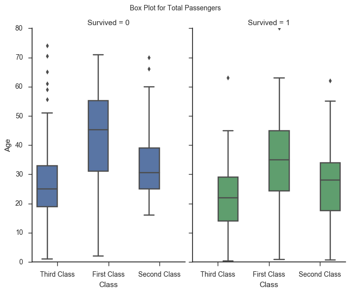

```python
g = sns.factorplot( x="Class",y="Age", hue="Survived", data = df,
               col="Survived",  kind="box", size=6, aspect=.6);

plt.subplots_adjust(top=0.9)
g.fig.suptitle('Box Plot for Total Passengers')
```

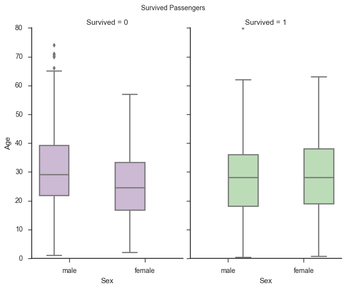

```python
g = sns.factorplot( x="Sex",y="Age", hue="Survived", data = df,palette="PRGn",
               col="Survived",  kind="box", size=6, aspect=.6);
plt.subplots_adjust(top=0.9)
g.fig.suptitle('Survived Passengers')
```

To get the idea of how many passengers died as compared to those who survived we can see the below plot.

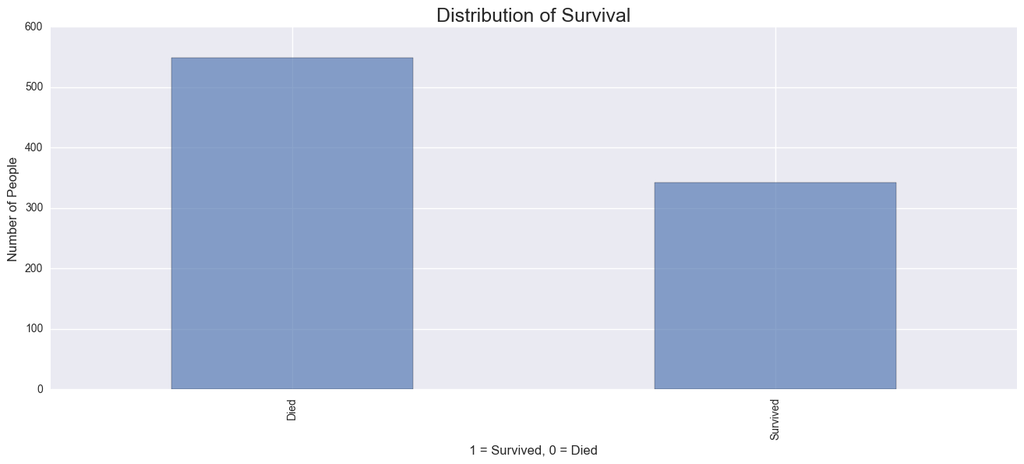

```python
def plotting(x_label, y_label, title, plot):
    # Add title and axis labels
    plot.set_xlabel(x_label, fontsize=12)
    plot.set_ylabel(y_label, fontsize=12)
    plot.set_title(title, fontsize=18)
    plt.show()

p = df['Survival'].value_counts().plot(kind='bar', alpha = 0.65,figsize=(16,6))

plotting( '1 = Survived, 0 = Died', 'Number of People', "Distribution of Survival", p)
```

Here we can see the total no of passengers who were died and who survived. Now let's calculate the average between the survival rates:

```python
#Probability of Survival by Gender
df.groupby('Sex')['Survived'].mean()
```

```
Sex
female    0.742038
male      0.188908
Name: Survived, dtype: float64
```

```python
#Probability of Survival by Class
df.groupby('Class')['Survived'].mean()
```

```
Class
First Class     0.629630
Second Class    0.472826
Third Class     0.242363
Name: Survived, dtype: float64
```

```python
#Probability of Survival by Class and Gender
df.groupby(['Class', 'Sex'])['Survived'].mean()
```

```
Class         Sex
First Class   female    0.968085
              male      0.368852
Second Class  female    0.921053
              male      0.157407
Third Class   female    0.500000
              male      0.135447
Name: Survived, dtype: float64
```

This is quite significant! But wait! Proportions without the raw counts don't mean anything. 60% could mean 60/100 or 6/10, so to be more specific we can do the following function:

```python
Total = df.groupby(['Class', 'Sex', 'Survival']).apply(len)
print Total
```

```
Class         Sex     Survival
First Class   female  Died          3
                      Survived     91
              male    Died         77
                      Survived     45
Second Class  female  Died          6
                      Survived     70
              male    Died         91
                      Survived     17
Third Class   female  Died         72
                      Survived     72
              male    Died        300
                      Survived     47
dtype: int64
```

```python
import seaborn as sns
df2 = df[df['Age'] <=18]
print len(df2)
df2.groupby(['Class'])['Survived'].size()
print
```

```
139
```

Now let's check for the childrens survival rate.

```python
C_T = df2.groupby(['Class'])['Survived'].sum()
print C_T
```

```
Class
First Class     14
Second Class    23
Third Class     33
Name: Survived, dtype: int64
```

Here we can see there were total 139 childrens travelling out of which only 70 survived that means 50% of childrens survived.

But if we do more research we will see that childrens travelling in 1st class have 87.5% survival rate, and childrens travelling in 2nd class has 79.31% survival rate whereas childrens travelling in 3rd class has 35.10% survival rate.

Now let's check the data of passengers travelling in Cabin.

```python
#surv = df[df['Survived'] == 1]
df_s = surv.groupby(['Sex', 'Class','Cabin'])['Survived'].size().unstack('Sex').fillna(0)

print df_s.head()
print len(df_s)
```

```
Sex                female  male
Class       Cabin
First Class A16       1.0   0.0
            A20       0.0   1.0
            A23       0.0   1.0
            A26       0.0   1.0
            A31       0.0   1.0
101
```

```python
C_t = len(df_cabin) - len(df_s)
print C_t
```

```
103
```

```python
df_WCb = df[pd.isnull(df["Cabin"]) & df["Survived"] ]
print len(df_WCb)

# This gives the no of passengers without cabin who survived.
```

```
206
```

```python
len(df) - len(df_cabin)
```

```
687
```

Whereas there were 687 passangers without cabin out of which only 206 passangers survived, which means only 30% of total population without cabin survived which is far less than the percentage of survived cabin passangers.

We will now do some analysis of survival rates based on the ports.

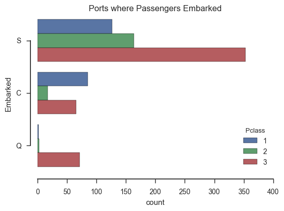

```python
g = sns.countplot(y="Embarked", hue="Pclass", data=df);
plt.subplots_adjust(top=0.9)
sns.plt.title('Ports where Passengers Embarked')
sns.despine(offset=10, trim=True)
```

We can see here the passangers who embarked on different ports classwise, which clearly shows that there were more passangers embarked on 'S' port as compared to other two ports. Let's do some deep research here.

```python
s = df[df['Embarked']== 'S']
S = s.groupby([ 'Embarked'])['Survival'].size().fillna(0)
print S
```

```
Embarked
S    644
dtype: int64
```

```python
s = df[df['Embarked']== 'S']
S = s.groupby([ 'Embarked'])['Survived'].sum().fillna(0)
print S
```

```
Embarked
S    217
Name: Survived, dtype: int64
```

Here we can see that 644 passangers embarked on port S out of which 217 survived means 33.69% population survived.

```python
c = df[df['Embarked']== 'C']
C = c.groupby([ 'Embarked'])['Survival'].size().fillna(0)
print C
```

```
Embarked
C    168
dtype: int64
```

```python
c = df[df['Embarked']== 'C']
C = c.groupby([ 'Embarked'])['Survived'].sum().fillna(0)
print C
```

```
Embarked
C    93
Name: Survived, dtype: int64
```

Here we can see that 168 passangers embarked on port C out of which 93 survived means 55.35% population survived.

```python
q = df[df['Embarked']== 'Q']
Q = q.groupby([ 'Embarked'])['Survival'].size().fillna(0)
print Q
```

```
Embarked
Q    77
dtype: int64
```

```python
q = df[df['Embarked']== 'Q']
Q = q.groupby([ 'Embarked'])['Survived'].sum().fillna(0)
print Q
```

```
Embarked
Q    30
Name: Survived, dtype: int64
```

Here we can see that 77 passangers embarked on port Q out of which 30 survived means 38.96% population survived.

So based on all the analysis my hypothesis is, there were more passengers travelling in class 3 as compared to other two classes, and there were more males on the ship as compared to females but the survival rate clearly shows that female passengers survived more as compared to the males, though there are some missing age values due to which we can't predict what was the exact survival rate, as they can be childrens or adults because it may affect the result. So we can predict that may be female were put on the lifeboat first but that too according to their classes that means 1st class female passengers were allowed in lifeboats first, then second and then third. After all the females same way was followed for the males, but this is all hypothesis because so many age values are missing, and can't predict exactly. Also after the 'cabin' analysis, it is clear that passengers having cabins were more likely to survive, again most of the passengers travelling in 1st class had cabins as compared to 2nd and 3rd. Or may be the location of the cabins was responsible for the survival rate. So can't say anything for sure.This dataset was at least in part collected after the titanic sank since we have the Survived variable. But this means that we will have more data available from those that survived. After all, it's very hard to survey a dead person!

For me the most intresting part was to analyse passengers according to the ports they 'embarked' and 'cabin'. I enjoyed analysing the data, and hope you like my analysis too.